# Solution Session 3

Dr. Thomas Pollet, Northumbria University (thomas.pollet@northumbria.ac.uk)

2019-09-13 | disclaimer

## Questions.

The typical study in this dataset administered a pre-test to a sample of students. Subsequently, the teachers were told that a randomly selected subsample were ‘bloomers’ (students with substantial potential intellectual growth). All of the students were then administered a post-test and it was expected that the ones identified as bloomers would show a significantly higher increment in IQ growth than the control group (i.e., students not identified as bloomers). You might have heard of the [Pygmalion effect](https://www.duq.edu/about/centers-and-institutes/center-for-teaching-excellence/teaching-and-learning/pygmalion), (see [here](https://en.wikipedia.org/wiki/Pygmalion_in_the_Classroom))

Inspect the data and note that it has *yi*= standardized mean difference and *vi*= corresponding sampling variance.

- Conduct a fixed-effects meta-analysis. Note that you’ll need to calculate the standard error.
- Conduct a random-effects model with the **DerSimonian-Laird** method.
- Conduct a random-effects model with the **Hartung-Knapp-Sidik-Jonkman** method.
- Conduct a random-effects model with **Restricted Maximum Likelihood (REML)** estimation, look at the `meta` package, if you don’t know how to.
- Make a ‘nice’ forest plot for one of your models. (**Bonus**: see if you manage to combine author and year on your forest plot).

## Load and manipulate the data

There are 19 studies.

```r
library(meta)
library(metafor)
Data<-dat.raudenbush1985
head(Data)
```

```
##   study             author year weeks setting tester n1i n2i      yi
## 1     1   Rosenthal et al. 1974     2   group  aware  77 339  0.0300
## 2     2        Conn et al. 1968    21   group  aware  60 198  0.1200
## 3     3        Jose & Cody 1971    19   group  aware  72  72 -0.1400
## 4     4 Pellegrini & Hicks 1972     0   group  aware  11  22  1.1800
## 5     5 Pellegrini & Hicks 1972     0   group  blind  11  22  0.2600
## 6     6  Evans & Rosenthal 1969     3   group  aware 129 348 -0.0600
##       vi
## 1 0.0156
## 2 0.0216
## 3 0.0279
## 4 0.1391
## 5 0.1362
## 6 0.0106
```

I have made the names as in our slides. Note that this is unnecessary duplication (as TE = *yi* ) but then it maps on nicely to our code.

```r
library(dplyr)
Data <- Data %>% mutate(TE=yi, seTE=sqrt(vi))
```

## Fixed effects model

```r
Fixed<-metagen(TE,
        seTE,
        data=Data,
        studlab=paste(author),
        comb.fixed = TRUE,
        comb.random = FALSE,
        prediction=TRUE,
        sm="SMD")
```

```r
Fixed
```

```
##                          SMD            95%-CI %W(fixed)
## Rosenthal et al.      0.0300 [-0.2148; 0.2748]       8.5
## Conn et al.           0.1200 [-0.1681; 0.4081]       6.2
## Jose & Cody          -0.1400 [-0.4674; 0.1874]       4.8
## Pellegrini & Hicks    1.1800 [ 0.4490; 1.9110]       1.0
## Pellegrini & Hicks    0.2600 [-0.4633; 0.9833]       1.0
## Evans & Rosenthal    -0.0600 [-0.2618; 0.1418]      12.5
## Fielder et al.       -0.0200 [-0.2218; 0.1818]      12.5
## Claiborn             -0.3200 [-0.7512; 0.1112]       2.7
## Kester                0.2700 [-0.0515; 0.5915]       4.9
## Maxwell               0.8000 [ 0.3081; 1.2919]       2.1
## Carter                0.5400 [-0.0519; 1.1319]       1.5
## Flowers               0.1800 [-0.2569; 0.6169]       2.7
## Keshock              -0.0200 [-0.5864; 0.5464]       1.6
## Henrikson             0.2300 [-0.3384; 0.7984]       1.6
## Fine                 -0.1800 [-0.4918; 0.1318]       5.3
## Grieger              -0.0600 [-0.3874; 0.2674]       4.8
## Rosenthal & Jacobson  0.3000 [ 0.0277; 0.5723]       6.9
## Fleming & Anttonen    0.0700 [-0.1139; 0.2539]      15.1
## Ginsburg             -0.0700 [-0.4112; 0.2712]       4.4
##
## Number of studies combined: k = 19
##
##                        SMD            95%-CI    z p-value
## Fixed effect model  0.0604 [-0.0111; 0.1318] 1.66  0.0979
## Prediction interval        [-0.2701; 0.4487]
##
## Quantifying heterogeneity:
## tau^2 = 0.0259; H = 1.41 [1.08; 1.84]; I^2 = 49.8% [14.7%; 70.4%]
##
## Test of heterogeneity:
##      Q d.f. p-value
##  35.83   18  0.0074
##
## Details on meta-analytical method:
## - Inverse variance method
```

## Random effects model (DL method)

Perhaps unsurprisingly one would draw same the fundamental conclusion that there is no significant effect (though note this analysis the effect is estimated to be slightly larger .0893 vs. .0604).

```r
Random_dl<-metagen(TE,
        seTE,
        data=Data,
        studlab=paste(author),
        comb.fixed = FALSE,
        comb.random = TRUE,
        hakn = FALSE,
        sm="SMD")
Random_dl
```

```
##                          SMD            95%-CI %W(random)
## Rosenthal et al.      0.0300 [-0.2148; 0.2748]        7.5
## Conn et al.           0.1200 [-0.1681; 0.4081]        6.6
## Jose & Cody          -0.1400 [-0.4674; 0.1874]        5.8
## Pellegrini & Hicks    1.1800 [ 0.4490; 1.9110]        1.9
## Pellegrini & Hicks    0.2600 [-0.4633; 0.9833]        1.9
## Evans & Rosenthal    -0.0600 [-0.2618; 0.1418]        8.5
## Fielder et al.       -0.0200 [-0.2218; 0.1818]        8.5
## Claiborn             -0.3200 [-0.7512; 0.1112]        4.2
## Kester                0.2700 [-0.0515; 0.5915]        5.9
## Maxwell               0.8000 [ 0.3081; 1.2919]        3.5
## Carter                0.5400 [-0.0519; 1.1319]        2.7
## Flowers               0.1800 [-0.2569; 0.6169]        4.1
## Keshock              -0.0200 [-0.5864; 0.5464]        2.8
## Henrikson             0.2300 [-0.3384; 0.7984]        2.8
## Fine                 -0.1800 [-0.4918; 0.1318]        6.1
## Grieger              -0.0600 [-0.3874; 0.2674]        5.8
## Rosenthal & Jacobson  0.3000 [ 0.0277; 0.5723]        6.9
## Fleming & Anttonen    0.0700 [-0.1139; 0.2539]        9.0
## Ginsburg             -0.0700 [-0.4112; 0.2712]        5.5
##
## Number of studies combined: k = 19
##
##                         SMD            95%-CI    z p-value
## Random effects model 0.0893 [-0.0200; 0.1987] 1.60  0.1094
##
## Quantifying heterogeneity:
## tau^2 = 0.0259; H = 1.41 [1.08; 1.84]; I^2 = 49.8% [14.7%; 70.4%]
##
## Test of heterogeneity:
##      Q d.f. p-value
##  35.83   18  0.0074
##
## Details on meta-analytical method:
## - Inverse variance method
## - DerSimonian-Laird estimator for tau^2
```

## Random effects model (Hartung-Knapp-Sidik-Jonkman method)

When this correction is applied we see that the confidence interval is somewhat widened, compared to when no correction is applied.

```r
model_hksj<-metagen(TE,
        seTE,
        data=Data,
        studlab=paste(author),
        comb.fixed = FALSE,
        comb.random = TRUE,
        method.tau = "SJ",
        hakn = TRUE,
        prediction=TRUE,
        sm="SMD")
model_hksj
```

```
##                          SMD            95%-CI %W(random)
## Rosenthal et al.      0.0300 [-0.2148; 0.2748]        6.6
## Conn et al.           0.1200 [-0.1681; 0.4081]        6.2
## Jose & Cody          -0.1400 [-0.4674; 0.1874]        5.8
## Pellegrini & Hicks    1.1800 [ 0.4490; 1.9110]        2.8
## Pellegrini & Hicks    0.2600 [-0.4633; 0.9833]        2.9
## Evans & Rosenthal    -0.0600 [-0.2618; 0.1418]        6.9
## Fielder et al.       -0.0200 [-0.2218; 0.1818]        6.9
## Claiborn             -0.3200 [-0.7512; 0.1112]        4.9
## Kester                0.2700 [-0.0515; 0.5915]        5.9
## Maxwell               0.8000 [ 0.3081; 1.2919]        4.3
## Carter                0.5400 [-0.0519; 1.1319]        3.6
## Flowers               0.1800 [-0.2569; 0.6169]        4.8
## Keshock              -0.0200 [-0.5864; 0.5464]        3.8
## Henrikson             0.2300 [-0.3384; 0.7984]        3.8
## Fine                 -0.1800 [-0.4918; 0.1318]        5.9
## Grieger              -0.0600 [-0.3874; 0.2674]        5.8
## Rosenthal & Jacobson  0.3000 [ 0.0277; 0.5723]        6.3
## Fleming & Anttonen    0.0700 [-0.1139; 0.2539]        7.1
## Ginsburg             -0.0700 [-0.4112; 0.2712]        5.7
##
## Number of studies combined: k = 19
##
##                         SMD            95%-CI    t p-value
## Random effects model 0.1133 [-0.0355; 0.2622] 1.60  0.1270
## Prediction interval         [-0.4914; 0.7181]
##
## Quantifying heterogeneity:
## tau^2 = 0.0771; H = 1.41 [1.08; 1.84]; I^2 = 49.8% [14.7%; 70.4%]
##
## Test of heterogeneity:
##      Q d.f. p-value
##  35.83   18  0.0074
##
## Details on meta-analytical method:
## - Inverse variance method
## - Sidik-Jonkman estimator for tau^2
## - Hartung-Knapp adjustment for random effects model
```

## REML estimation.

This is REML estimation which maps on Table 16.2 (Simple Random Effects model) (as an aside, note $\tau^2$ estimate in this model as opposed to the above).

```r
model_reml<-metagen(TE,
        seTE,
        data=Data,
        studlab=paste(author),
        comb.fixed = FALSE,
        comb.random = TRUE,
        method.tau = "REML",
        hakn = FALSE,
        prediction=TRUE,
        sm="SMD")
model_reml
```

```
##                          SMD            95%-CI %W(random)
## Rosenthal et al.      0.0300 [-0.2148; 0.2748]        7.7
## Conn et al.           0.1200 [-0.1681; 0.4081]        6.6
## Jose & Cody          -0.1400 [-0.4674; 0.1874]        5.7
## Pellegrini & Hicks    1.1800 [ 0.4490; 1.9110]        1.7
## Pellegrini & Hicks    0.2600 [-0.4633; 0.9833]        1.7
## Evans & Rosenthal    -0.0600 [-0.2618; 0.1418]        9.1
## Fielder et al.       -0.0200 [-0.2218; 0.1818]        9.1
## Claiborn             -0.3200 [-0.7512; 0.1112]        4.0
## Kester                0.2700 [-0.0515; 0.5915]        5.8
## Maxwell               0.8000 [ 0.3081; 1.2919]        3.3
## Carter                0.5400 [-0.0519; 1.1319]        2.4
## Flowers               0.1800 [-0.2569; 0.6169]        3.9
## Keshock              -0.0200 [-0.5864; 0.5464]        2.6
## Henrikson             0.2300 [-0.3384; 0.7984]        2.6
## Fine                 -0.1800 [-0.4918; 0.1318]        6.0
## Grieger              -0.0600 [-0.3874; 0.2674]        5.7
## Rosenthal & Jacobson  0.3000 [ 0.0277; 0.5723]        7.0
## Fleming & Anttonen    0.0700 [-0.1139; 0.2539]        9.7
## Ginsburg             -0.0700 [-0.4112; 0.2712]        5.4
##
## Number of studies combined: k = 19
##
##                         SMD            95%-CI    z p-value
## Random effects model 0.0837 [-0.0175; 0.1849] 1.62  0.1051
## Prediction interval         [-0.2256; 0.3930]
##
## Quantifying heterogeneity:
## tau^2 = 0.0188; H = 1.41 [1.08; 1.84]; I^2 = 49.8% [14.7%; 70.4%]
##
## Test of heterogeneity:
##      Q d.f. p-value
##  35.83   18  0.0074
##
## Details on meta-analytical method:
## - Inverse variance method
## - Restricted maximum-likelihood estimator for tau^2
```

## Forest plot.

Let’s combine, author and year.

Let’s bracket the year as per convention. Here I rely on base R and [this snippet](https://stackoverflow.com/questions/29884082/apply-parentheses-around-elements-of-r-dataframe).

```r
Data$year_b <- paste0("(", format(unlist(Data[,3])),")")
```

Then we combine as done in [here](https://stackoverflow.com/questions/18115550/combine-two-or-more-columns-in-a-dataframe-into-a-new-column-with-a-new-name). Here I have opted for a ‘[tidyverse](https://www.tidyverse.org/)’ solution.

```r
library(tidyverse)
Data <-Data %>% unite(author_year, c(author, year_b), sep = " ", remove = FALSE)
```

Let’s redo our model but now with `author_year`.

```r
model_reml2<-metagen(TE,
        seTE,
        data=Data,
        studlab=paste(author_year),
        comb.fixed = FALSE,
        comb.random = TRUE,
        method.tau = "REML",
        hakn = FALSE,
        prediction=TRUE,
        sm="SMD")
model_reml2
```

```
##                                 SMD            95%-CI %W(random)
## Rosenthal et al. (1974)      0.0300 [-0.2148; 0.2748]        7.7
## Conn et al. (1968)           0.1200 [-0.1681; 0.4081]        6.6
## Jose & Cody (1971)          -0.1400 [-0.4674; 0.1874]        5.7
## Pellegrini & Hicks (1972)    1.1800 [ 0.4490; 1.9110]        1.7
## Pellegrini & Hicks (1972)    0.2600 [-0.4633; 0.9833]        1.7
## Evans & Rosenthal (1969)    -0.0600 [-0.2618; 0.1418]        9.1
## Fielder et al. (1971)       -0.0200 [-0.2218; 0.1818]        9.1
## Claiborn (1969)             -0.3200 [-0.7512; 0.1112]        4.0
## Kester (1969)                0.2700 [-0.0515; 0.5915]        5.8
## Maxwell (1970)               0.8000 [ 0.3081; 1.2919]        3.3
## Carter (1970)                0.5400 [-0.0519; 1.1319]        2.4
## Flowers (1966)               0.1800 [-0.2569; 0.6169]        3.9
## Keshock (1970)              -0.0200 [-0.5864; 0.5464]        2.6
## Henrikson (1970)             0.2300 [-0.3384; 0.7984]        2.6
## Fine (1972)                 -0.1800 [-0.4918; 0.1318]        6.0
## Grieger (1970)              -0.0600 [-0.3874; 0.2674]        5.7
## Rosenthal & Jacobson (1968)  0.3000 [ 0.0277; 0.5723]        7.0
## Fleming & Anttonen (1971)    0.0700 [-0.1139; 0.2539]        9.7
## Ginsburg (1970)             -0.0700 [-0.4112; 0.2712]        5.4
##
## Number of studies combined: k = 19
##
##                         SMD            95%-CI    z p-value
## Random effects model 0.0837 [-0.0175; 0.1849] 1.62  0.1051
## Prediction interval         [-0.2256; 0.3930]
##
## Quantifying heterogeneity:
## tau^2 = 0.0188; H = 1.41 [1.08; 1.84]; I^2 = 49.8% [14.7%; 70.4%]
##
## Test of heterogeneity:
##      Q d.f. p-value
##  35.83   18  0.0074
##
## Details on meta-analytical method:
## - Inverse variance method
## - Restricted maximum-likelihood estimator for tau^2
```

Note that this is but one solution.

Unfortunately this doesn’t fit nicely, unless you mess about with the chunk options in `knitr`. So let’s also export it as .pdf . Have a look at the `meta` manual manual, you can modify a bunch of other things.

```r
forest(model_reml2,
       sortvar=TE,
       xlim = c(-1,2),
       rightlabs = c("SMD","95% CI","weight"),
       leftlabs = c("Author", "SMD", "SE"),
       pooled.totals = FALSE,
       smlab = "",
       text.random = "Overall effect",
       print.tau2 = FALSE,
       col.diamond = "darkblue",
       col.diamond.lines = "black",
       col.predict = "black",
       print.I2.ci = TRUE,
       digits.sd = 2
)
```

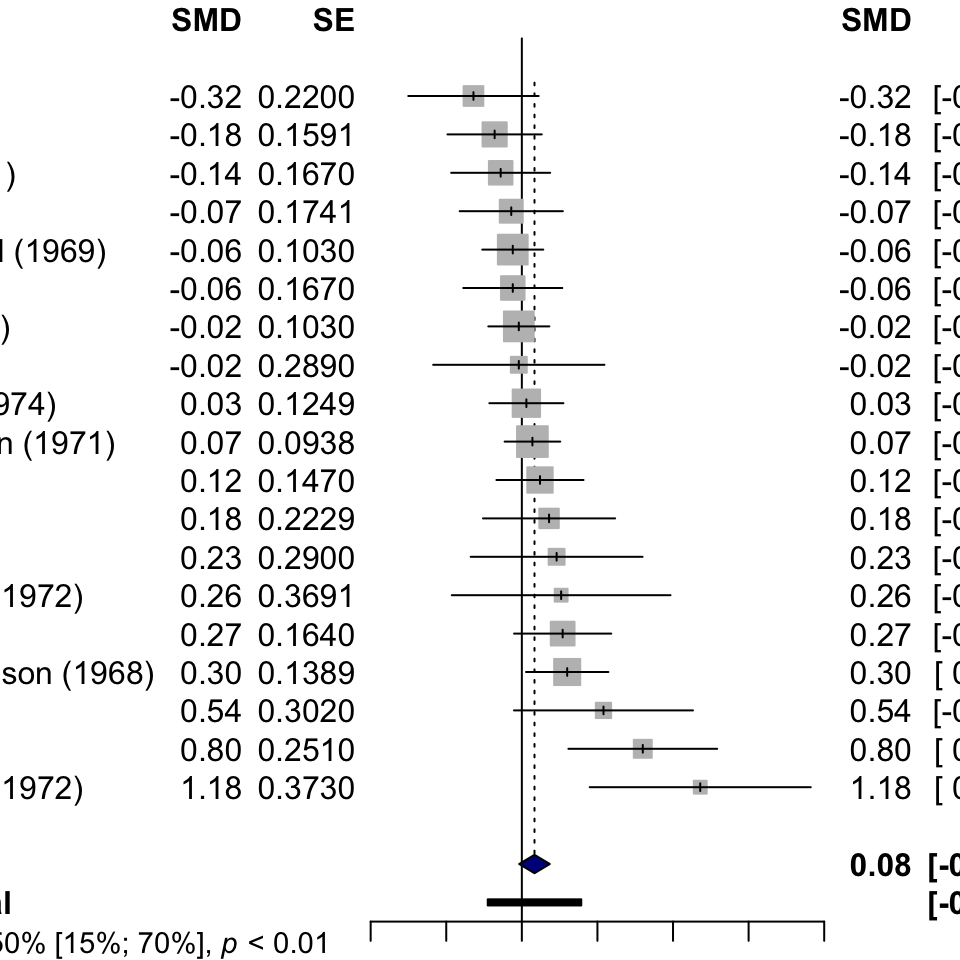

```r
pdf(file='forestplot_pygmalion.pdf',width=10,height=8)
forest(model_reml,
       sortvar=TE,
       xlim = c(-1,2),
       rightlabs = c("SMD","95% CI","weight"),
       leftlabs = c("Author", "N","Mean","SD","N","Mean","SD"),
       lab.e = "Intervention",
       pooled.totals = FALSE,
       smlab = "",
       text.random = "Overall effect",
       print.tau2 = FALSE,
       col.diamond = "darkblue",
       col.diamond.lines = "black",
       col.predict = "black",
       print.I2.ci = TRUE,
       digits.sd = 2
)
```

Note that there is some unnecessary duplication in the plot but it seems that ‘leftlabs’ cannot be modified easily… .

Here is an example of using ‘JAMA’.

```r
pdf(file='JAMA_forestplot_pygmalion.pdf', width=10,height=8)
forest(model_reml2,
       sortvar=TE,
      layout='JAMA'
)
```

You should get something like below.

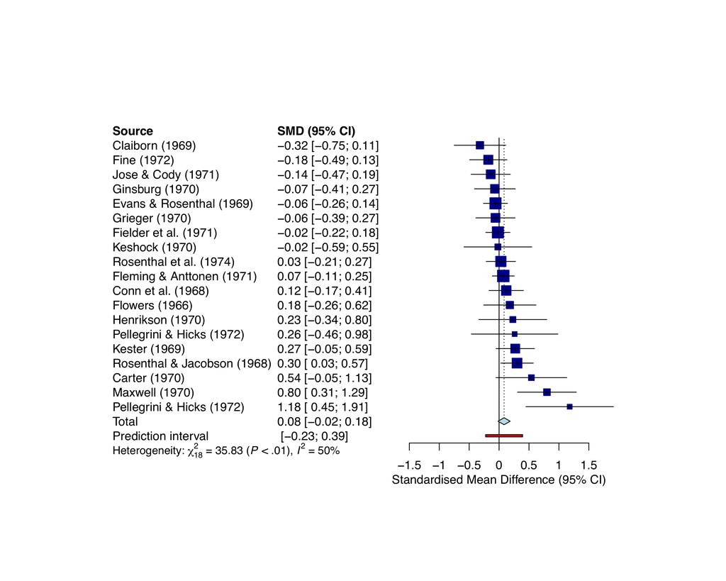

## The end.

The end.

[figure not shown]

## Acknowledgments and further reading… .

The example is from [here](http://www.metafor-project.org/doku.php/analyses:raudenbush2009#fixed-effects_model).

Note that throughout I have varied the rounding when I reported, you should make your own decisions on how precise you believe your results to be.

Please see the slides for further reading.

**Cited literature**

Raudenbush, S. W. (1984). Magnitude of teacher expectancy effects on pupil IQ as a function of the credibility of expectancy induction: A synthesis of findings from 18 experiments. *Journal of Educational Psychology, 76(1)*, 85–97.

Raudenbush, S. W. (2009). Analyzing effect sizes: Random effects models. In H. Cooper, L. V. Hedges, & J. C. Valentine (Eds.), *The handbook of research synthesis and meta-analysis* (2nd ed., pp. 295–315). New York: Russell Sage Foundation.